# A3

```r
payment_type_f<- as.factor(tripdata_df$payment_type)
is.factor(payment_type_f)
```

```
## [1] TRUE
```

```r
levels(payment_type_f)
```

```
## [1] "1" "2" "3" "4" "5"
```

Question 2- Analyze the data to determine what is the most common way that people: a) hail a cab and b) pay for the trip. Helpful fields are: trip_type and payment_type. Explain your results.

```r
# For a) Without visualization
tripdata_df %>%
  count(trip_type, sort = TRUE)
```

```
## # A tibble: 3 x 2
##   trip_type      n
##       <dbl>  <int>
## 1         1 310466
## 2        NA  80894
## 3         2   7272
```

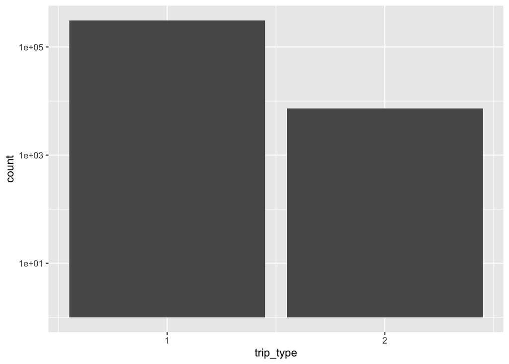

```r
#With bar graph
ggplot(data= tripdata_df) +
  geom_bar( aes (x= trip_type)) + scale_x_continuous(breaks= c(1,2)) + scale_y_log10()
```

```r
#Most people prefer street hail which is represented by code 1. 310,466 trips have been hailed in that manner

# For b) Without visualization
tripdata_df %>%
  count(payment_type, sort = TRUE)
```

```
## # A tibble: 6 x 2
##   payment_type      n
##          <dbl>  <int>
## 1            1 176530
## 2            2 138849
## 3           NA  80893
## 4            3   1767
## 5            4    579
## 6            5     14
```

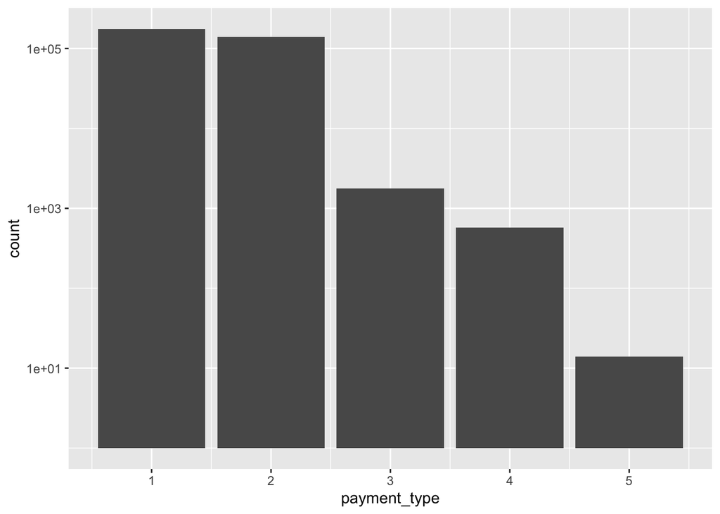

```r
#With bar graph
ggplot(data= tripdata_df) +
  geom_bar( aes (x= payment_type)) + scale_x_continuous(breaks= c(1,2,3,4,5)) + scale_y_log10()
```

```r
#Most people pay via Credit card which is represented by code 1. 176,530 trips have been paid through credit card
```

Question 3 — Count the frequency of pickups for each day in February. Visualize the results using a bar chart and show the frequency on the y-axis and the date on the x-axis. Do you detect any patterns? What are your observations? Note: do not include the time in your calculations or the visualization (only use the date)

```r
tripdata_df <- tripdata_df %>%
mutate (day = factor(mday(lpep_pickup_datetime)))
tripdata_df
```

```
## # A tibble: 398,632 x 21
##    VendorID lpep_pickup_datetime lpep_dropoff_datet… store_and_fwd_f… RatecodeID
##       <dbl> <dttm>               <dttm>              <chr>                 <dbl>
##  1        2 2020-02-01 00:10:25  2020-02-01 00:14:34 N                         1
##  2        2 2020-02-01 00:16:59  2020-02-01 00:21:35 N                         1
##  3        2 2020-02-01 00:19:31  2020-02-01 00:25:29 N                         1
##  4        2 2020-02-01 00:43:52  2020-02-01 00:48:58 N                         1
##  5        2 2020-02-01 00:32:53  2020-02-01 00:35:19 N                         1
##  6        2 2020-02-01 00:04:36  2020-02-01 00:10:09 N                         1
##  7        2 2020-02-01 00:49:36  2020-02-01 01:07:27 N                         1
##  8        2 2020-02-01 00:21:08  2020-02-01 00:28:16 N                         1
##  9        2 2020-02-01 00:05:16  2020-02-01 00:16:25 N                         1
## 10        2 2020-02-01 00:59:48  2020-02-01 01:06:26 N                         1
## # … with 398,622 more rows, and 16 more variables: PULocationID <dbl>,
## #   DOLocationID <dbl>, passenger_count <dbl>, trip_distance <dbl>,
## #   fare_amount <dbl>, extra <dbl>, mta_tax <dbl>, tip_amount <dbl>,
## #   tolls_amount <dbl>, ehail_fee <lgl>, improvement_surcharge <dbl>,
## #   total_amount <dbl>, payment_type <dbl>, trip_type <dbl>,
## #   congestion_surcharge <dbl>, day <fct>
```